# P1-Automobile

## AutoMobile

**CONTEXT:** The data concerns city-cycle fuel consumption in miles per gallon, to be predicted in terms of 3 multivalued discrete and 5 continuous attributes

DATA DESCRIPTION: The data concerns city-cycle fuel consumption in miles per gallon

Attribute Information:

1. mpg: continuous
2. cylinders: multi-valued discrete
3. displacement: continuous
4. horsepower: continuous
5. weight: continuous
6. acceleration: continuous
7. model year: multi-valued discrete
8. origin: multi-valued discrete
9. car name: string (unique for each instance)

**PROJECT OBJECTIVE:** Goal is to cluster the data and treat them as individual datasets to train Regression models to predict ‘mpg’

```python
import pandas as pd
import numpy as np
import os
from sklearn.cluster import KMeans
from sklearn.preprocessing import LabelEncoder
from sklearn.preprocessing import MinMaxScaler
import seaborn as sns
import matplotlib.pyplot as plt
%matplotlib inline
```

### 1. Import datasets

1. Import and warehouse data: [ Score: 3 points ] • Import all the given datasets and explore shape and size. • Merge all datasets onto one and explore final shape and size. • Export the final dataset and store it on local machine in .csv, .xlsx and .json format for future use. • Import the data from above steps into python

```python
#import req datasets
carname = pd.read_csv("Part1 - Car name.csv")
carAttrib = pd.read_json("Part1 - Car-Attributes.json")
```

```python
print(f"Dataset Shapes")
print(f"CarNames dataset: {carname.shape}")
print(f"carAttrib dataset: {carAttrib.shape}")
```

```
Dataset Shapes
CarNames dataset: (398, 1)
carAttrib dataset: (398, 8)
```

```python
carname.head()
```

|  | car_name |
| --- | --- |
| 0 | chevrolet chevelle malibu |
| 1 | buick skylark 320 |
| 2 | plymouth satellite |
| 3 | amc rebel sst |
| 4 | ford torino |

```python
carAttrib.head()
```

|  | mpg | cyl | disp | hp | wt | acc | yr | origin |
| --- | --- | --- | --- | --- | --- | --- | --- | --- |
| 0 | 18.0 | 8 | 307.0 | 130 | 3504 | 12.0 | 70 | 1 |
| 1 | 15.0 | 8 | 350.0 | 165 | 3693 | 11.5 | 70 | 1 |
| 2 | 18.0 | 8 | 318.0 | 150 | 3436 | 11.0 | 70 | 1 |
| 3 | 16.0 | 8 | 304.0 | 150 | 3433 | 12.0 | 70 | 1 |
| 4 | 17.0 | 8 | 302.0 | 140 | 3449 | 10.5 | 70 | 1 |

```python
#Merge the datasets
frames = [carname, carAttrib]
dataset = pd.concat(frames, axis=1)
dataset.head()
```

|  | car_name | mpg | cyl | disp | hp | wt | acc | yr | origin |
| --- | --- | --- | --- | --- | --- | --- | --- | --- | --- |
| 0 | chevrolet chevelle malibu | 18.0 | 8 | 307.0 | 130 | 3504 | 12.0 | 70 | 1 |
| 1 | buick skylark 320 | 15.0 | 8 | 350.0 | 165 | 3693 | 11.5 | 70 | 1 |
| 2 | plymouth satellite | 18.0 | 8 | 318.0 | 150 | 3436 | 11.0 | 70 | 1 |
| 3 | amc rebel sst | 16.0 | 8 | 304.0 | 150 | 3433 | 12.0 | 70 | 1 |
| 4 | ford torino | 17.0 | 8 | 302.0 | 140 | 3449 | 10.5 | 70 | 1 |

```python
#Store the merged dataset in a new file and read from it
dataset.to_csv('Automobile_dataset.csv', index=False)
autods = pd.read_csv('Automobile_dataset.csv')
autods.head()
```

|  | car_name | mpg | cyl | disp | hp | wt | acc | yr | origin |
| --- | --- | --- | --- | --- | --- | --- | --- | --- | --- |
| 0 | chevrolet chevelle malibu | 18.0 | 8 | 307.0 | 130 | 3504 | 12.0 | 70 | 1 |
| 1 | buick skylark 320 | 15.0 | 8 | 350.0 | 165 | 3693 | 11.5 | 70 | 1 |
| 2 | plymouth satellite | 18.0 | 8 | 318.0 | 150 | 3436 | 11.0 | 70 | 1 |
| 3 | amc rebel sst | 16.0 | 8 | 304.0 | 150 | 3433 | 12.0 | 70 | 1 |
| 4 | ford torino | 17.0 | 8 | 302.0 | 140 | 3449 | 10.5 | 70 | 1 |

### 3. Data cleansing

• Missing/incorrect value treatment • Drop attribute/s if required using relevant functional knowledge • Perform another kind of corrections/treatment on the data

```python
autods.info()
```

```
<class 'pandas.core.frame.DataFrame'>
RangeIndex: 398 entries, 0 to 397
Data columns (total 9 columns):
 #   Column    Non-Null Count  Dtype
---  ------    --------------  -----
 0   car_name  398 non-null    object
 1   mpg       398 non-null    float64
 2   cyl       398 non-null    int64
 3   disp      398 non-null    float64
 4   hp        398 non-null    object
 5   wt        398 non-null    int64
 6   acc       398 non-null    float64
 7   yr        398 non-null    int64
 8   origin    398 non-null    int64
dtypes: float64(3), int64(4), object(2)
memory usage: 28.1+ KB
```

```python
autods['origin'].unique()
```

```
array([1, 3, 2], dtype=int64)
```

```python
pd.DataFrame(autods.isnull().sum(), columns=['No. of missing values'])
```

|  | No. of missing values |
| --- | --- |
| car_name | 0 |
| mpg | 0 |
| cyl | 0 |
| disp | 0 |
| hp | 0 |
| wt | 0 |
| acc | 0 |
| yr | 0 |
| origin | 0 |

On inspection of the dataset, we see the horsepower column is marked with question marks.

```python
autods[autods['hp']=="?"]
```

|  | car_name | mpg | cyl | disp | hp | wt | acc | yr | origin |
| --- | --- | --- | --- | --- | --- | --- | --- | --- | --- |
| 32 | ford pinto | 25.0 | 4 | 98.0 | ? | 2046 | 19.0 | 71 | 1 |
| 126 | ford maverick | 21.0 | 6 | 200.0 | ? | 2875 | 17.0 | 74 | 1 |
| 330 | renault lecar deluxe | 40.9 | 4 | 85.0 | ? | 1835 | 17.3 | 80 | 2 |
| 336 | ford mustang cobra | 23.6 | 4 | 140.0 | ? | 2905 | 14.3 | 80 | 1 |
| 354 | renault 18i | 34.5 | 4 | 100.0 | ? | 2320 | 15.8 | 81 | 2 |
| 374 | amc concord dl | 23.0 | 4 | 151.0 | ? | 3035 | 20.5 | 82 | 1 |

```python
autods['hp'].replace("?",np.nan,inplace=True)
autods['hp'].fillna(autods['hp'].median(), inplace=True)
autods['hp'] = autods['hp'].astype('float')
```

```python
autods.shape
```

```
(398, 9)
```

### 3. Data Analysis and Visualization

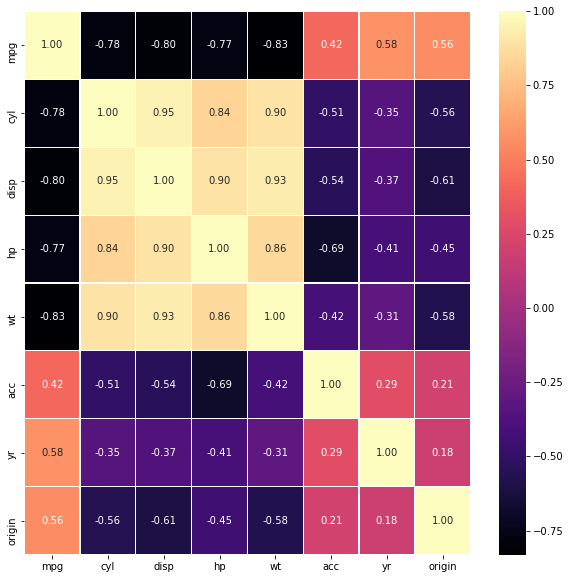

```python
fig,ax = plt.subplots(figsize=(10, 10))
sns.heatmap(autods.corr(), ax=ax, annot=True, linewidths=0.05, fmt= '.2f',cmap="magma") # the color intensity is based on
plt.show()
```

There is a high co-relation between cylinder and displacement and we can consider removing the displacement column.

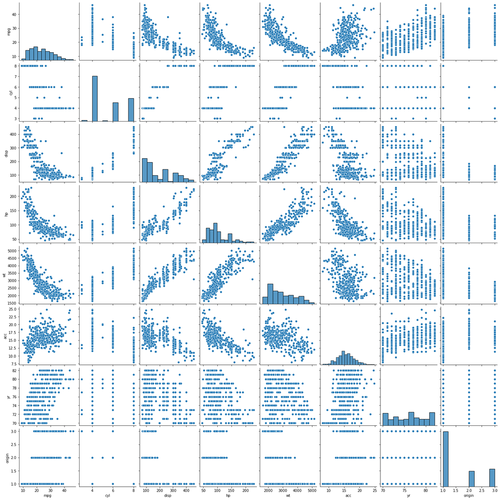

```python
sns.pairplot(autods)
```

We can observe a normal distribution for acceleration. We also observe a linear relationship between various variables.

```python
# Calculate age of vehicle. The dataset is from 1983.
autods['age'] = 83-autods['yr']
autods.head()
```

|  | car_name | mpg | cyl | disp | hp | wt | acc | yr | origin | age |
| --- | --- | --- | --- | --- | --- | --- | --- | --- | --- | --- |
| 0 | chevrolet chevelle malibu | 18.0 | 8 | 307.0 | 130.0 | 3504 | 12.0 | 70 | 1 | 13 |
| 1 | buick skylark 320 | 15.0 | 8 | 350.0 | 165.0 | 3693 | 11.5 | 70 | 1 | 13 |
| 2 | plymouth satellite | 18.0 | 8 | 318.0 | 150.0 | 3436 | 11.0 | 70 | 1 | 13 |
| 3 | amc rebel sst | 16.0 | 8 | 304.0 | 150.0 | 3433 | 12.0 | 70 | 1 | 13 |
| 4 | ford torino | 17.0 | 8 | 302.0 | 140.0 | 3449 | 10.5 | 70 | 1 | 13 |

```python
#The year of manufacturing column is now redundant, since age will give better insight
```

```python
autods = autods.drop(['yr', 'car_name'], axis=1)
```

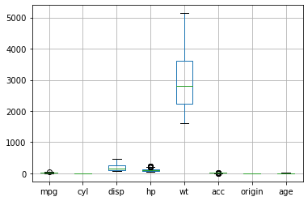

```python
## Check for outliers
autods.boxplot();
```

There are a few outliers for mpg, hp and acc

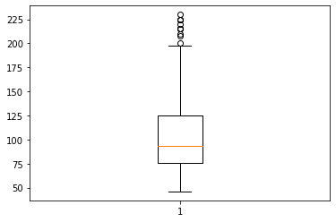

```python
plt.boxplot(autods['hp']);
```

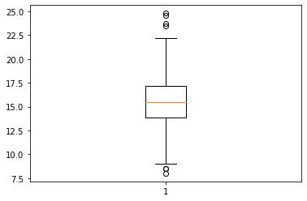

```python
plt.boxplot(autods['acc']);
```

```python
#Take log to remove the outliers
#When our original continuous data do not follow the bell curve,
#we can log transform this data to make it as “normal” as possible
#so that the statistical analysis results from this data become more valid .
#In other words, the log transformation reduces or removes the skewness of
#our original data.
autods['hp'] = np.log(autods['hp'])
autods['acc'] = np.log(autods['acc'])
autods['mpg'] = np.log(autods['mpg'])
autods.head()
```

|  | mpg | cyl | disp | hp | wt | acc | origin | age |
| --- | --- | --- | --- | --- | --- | --- | --- | --- |
| 0 | 2.890372 | 8 | 307.0 | 4.867534 | 3504 | 2.484907 | 1 | 13 |
| 1 | 2.708050 | 8 | 350.0 | 5.105945 | 3693 | 2.442347 | 1 | 13 |
| 2 | 2.890372 | 8 | 318.0 | 5.010635 | 3436 | 2.397895 | 1 | 13 |
| 3 | 2.772589 | 8 | 304.0 | 5.010635 | 3433 | 2.484907 | 1 | 13 |
| 4 | 2.833213 | 8 | 302.0 | 4.941642 | 3449 | 2.351375 | 1 | 13 |

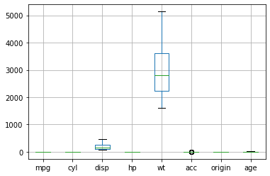

```python
autods.boxplot();
```

```python
## Applying scaling using z-score
from scipy.stats import zscore
numeric_cols = autods.select_dtypes(include=[np.int64, np.float64]).columns
autods[numeric_cols] = autods[numeric_cols].apply(zscore)
autods.head()
```

|  | mpg | cyl | disp | hp | wt | acc | origin | age |
| --- | --- | --- | --- | --- | --- | --- | --- | --- |
| 0 | -0.622035 | 1.498191 | 1.090604 | 0.823608 | 0.630870 | -1.353748 | -0.715145 | 1.627426 |
| 1 | -1.159493 | 1.498191 | 1.503514 | 1.523992 | 0.854333 | -1.589535 | -0.715145 | 1.627426 |
| 2 | -0.622035 | 1.498191 | 1.196232 | 1.243998 | 0.550470 | -1.835805 | -0.715145 | 1.627426 |
| 3 | -0.969242 | 1.498191 | 1.061796 | 1.243998 | 0.546923 | -1.353748 | -0.715145 | 1.627426 |
| 4 | -0.790530 | 1.498191 | 1.042591 | 1.041316 | 0.565841 | -2.093533 | -0.715145 | 1.627426 |

### 4. Machine Learning

Apply clustering

```python
cluster_range = range(1,15)
cluster_errors = []
for num_clusters in cluster_range:
    clusters = KMeans(num_clusters, n_init = 5)
    clusters.fit(autods)
    labels = clusters.labels_
    centroids = clusters.cluster_centers_
    cluster_errors.append(clusters.inertia_)

clusters_df = pd.DataFrame({"num_clusters": cluster_range, "cluster_errors": cluster_errors})
clusters_df[0:15]
```

|  | num_clusters | cluster_errors |
| --- | --- | --- |
| 0 | 1 | 3184.000000 |
| 1 | 2 | 1551.384503 |
| 2 | 3 | 1163.987759 |
| 3 | 4 | 970.780442 |
| 4 | 5 | 812.339380 |
| 5 | 6 | 735.396761 |
| 6 | 7 | 667.000288 |
| 7 | 8 | 631.391821 |
| 8 | 9 | 592.342718 |
| 9 | 10 | 558.111445 |
| 10 | 11 | 537.417377 |
| 11 | 12 | 502.847162 |
| 12 | 13 | 473.252942 |
| 13 | 14 | 445.458228 |

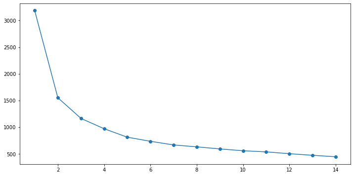

```python
#identify the appropriate cluster to select using the elbow technique
from matplotlib import cm

plt.figure(figsize=(12,6))
plt.plot( clusters_df.num_clusters, clusters_df.cluster_errors, marker = "o" );
```

At cluster size 4, we see the inflection point https://bl.ocks.org/rpgove/0060ff3b656618e9136b [plot a line chart of the SSE or inertia for each value of k. If the line chart looks like an arm, then the "elbow" on the arm is the value of k that is the best. The idea is that we want a small SSE, but that the SSE tends to decrease toward 0 as we increase k (the SSE is 0 when k is equal to the number of data points in the dataset, because then each data point is its own cluster, and there is no error between it and the center of its cluster). So our goal is to choose a small value of k that still has a low SSE, and the elbow usually represents where we start to have diminishing returns by increasing k.]

```python
#get the number of unique labels
np.unique(label)
```

[output not shown]

```python
kmeans = KMeans(n_clusters=4, n_init = 5, random_state=12345)
#kmeans.fit_predict method returns the array of cluster labels each data point belongs to.
autods['cluster'] = kmeans.fit_predict(autods)
```

```python
# Check the number of data in each cluster

#labels = kmeans.labels_
counts = np.bincount(labels[labels>=0])
print(counts)
```

```
[33 34 24 25 40 36 35 33 32 21 35 22 13 15]
```

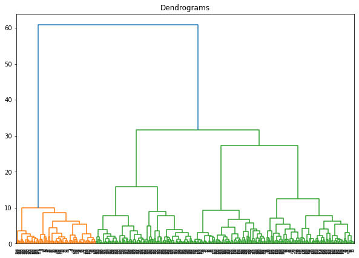

```python
import scipy.cluster.hierarchy as shc
plt.figure(figsize=(10, 7))
plt.title("Dendrograms")
dend = shc.dendrogram(shc.linkage(autods, method='ward'))
```

We can cut the dendogram at 20 to give us four clusters, which sufficiently seems to cluster the data well

```python
from sklearn.cluster import AgglomerativeClustering
cluster = AgglomerativeClustering(n_clusters=4, affinity='euclidean', linkage='ward')
autods['group'] = cluster.fit_predict(autods);
autods['group'] = autods['group'].astype('category')
```

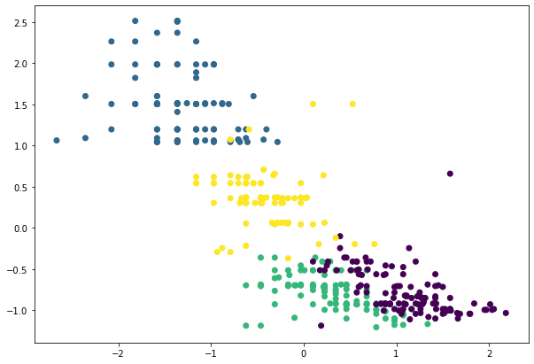

```python
plt.figure(figsize=(10, 7))
plt.scatter(autods['mpg'], autods['disp'], c=cluster.labels_)
```

**Insight about using the two methods**

--> For K-means we use the elbow method to find an inflection point to decide the number of clusters required. Whereas, for HC we use dendogram to find decide the clusters.

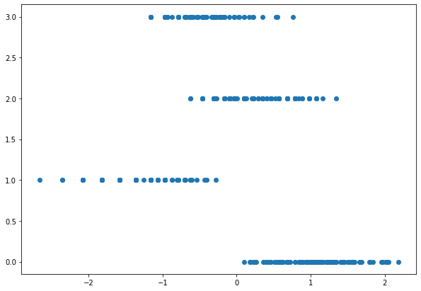

```python
plt.figure(figsize=(10, 7))
plt.scatter(autods['mpg'], cluster.labels_)
```

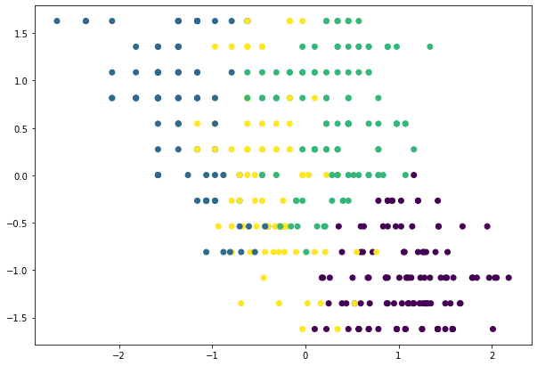

```python
plt.figure(figsize=(10, 7))
plt.scatter(autods['mpg'], autods['age'], c=cluster.labels_)
```

```python
autods.dtypes
```

```
mpg         float64
cyl         float64
disp        float64
hp          float64
wt          float64
acc         float64
origin      float64
age         float64
cluster       int32
group      category
dtype: object
```

### 5. Answers

**1. How many optimal clusters are present in the data and the possible reason behind it.**

--> We can consider four as the optimal number of clusters for the above data.

**5.2 Apply linear regression to different clusters**

```python
cluster1 = autods[autods['group']==0]
cluster2 = autods[autods['group']==1]
cluster3 = autods[autods['group']==2]
cluster4 = autods[autods['group']==3]
```

```python
cluster1.head()
```

|  | mpg | cyl | disp | hp | wt | acc | origin | age | cluster | group |
| --- | --- | --- | --- | --- | --- | --- | --- | --- | --- | --- |
| 198 | 1.164768 | -0.856321 | -0.983552 | -1.812237 | -1.389757 | 0.704774 | 1.781589 | 0.002721 | 3 | 0 |
| 216 | 1.027633 | -0.856321 | -0.916334 | -1.080112 | -1.094171 | 1.044389 | 1.781589 | -0.268063 | 3 | 0 |
| 217 | 0.883807 | -0.856321 | -0.791500 | -0.602677 | -0.964113 | -0.191862 | -0.715145 | -0.268063 | 3 | 0 |
| 218 | 1.421265 | -0.856321 | -1.098783 | -1.547399 | -1.354286 | 1.074255 | 0.533222 | -0.268063 | 3 | 0 |
| 220 | 1.209097 | -0.856321 | -1.041167 | -0.994955 | -1.212405 | 0.510363 | 1.781589 | -0.268063 | 3 | 0 |

```python
from sklearn.model_selection import train_test_split
from sklearn import linear_model
from sklearn.metrics import mean_squared_error, r2_score
```

Let's try to apply linear regression to predict mpg for a car for each cluster.

```python
y_C1 = cluster1['mpg']
X_C1 = cluster1.drop(columns=['mpg','group','cluster']) #remove colmns from prev computations
X_C1_train, X_C1_test, y_C1_train, y_C1_test = train_test_split(X_C1, y_C1, test_size=0.25, random_state=48)
```

```python
regr1 = linear_model.LinearRegression()
# Train the model using the training sets
regr1.fit(X_C1_train, y_C1_train)

# Make predictions using the testing set
y_C1_pred = regr1.predict(X_C1_test)

# The coefficients
print('Coefficients: \n', regr1.coef_)
# The mean squared error
print('Mean squared error: %.2f'
      % mean_squared_error(y_C1_test, y_C1_pred))
# The coefficient of determination: 1 is perfect prediction
print('Coefficient of determination: %.2f'
      % r2_score(y_C1_test, y_C1_pred))
```

```
Coefficients:
 [ 0.48343793  0.13580233 -0.334428   -0.5755247   0.02138677  0.05098255
 -0.19058735]
Mean squared error: 0.09
Coefficient of determination: 0.42
```

```python
y_C2 = cluster2['mpg']
X_C2 = cluster2.drop(columns=['mpg','group','cluster']) #remove colmns from prev computations
X_C2_train, X_C2_test, y_C2_train, y_C2_test = train_test_split(X_C2, y_C2, test_size=0.25, random_state=48)
```

```python
regr2 = linear_model.LinearRegression()
# Train the model using the training sets
regr2.fit(X_C2_train, y_C2_train)

# Make predictions using the testing set
y_C2_pred = regr2.predict(X_C2_test)

# The coefficients
print('Coefficients: \n', regr2.coef_)
# The mean squared error
print('Mean squared error: %.2f'
      % mean_squared_error(y_C2_test, y_C2_pred))
# The coefficient of determination: 1 is perfect prediction
print('Coefficient of determination: %.2f'
      % r2_score(y_C2_test, y_C2_pred))
```

```
Coefficients:
 [-0.17561883 -0.16178753 -0.40289068 -0.24900277 -0.32942843  0.02926981
 -0.27480009]
Mean squared error: 0.22
Coefficient of determination: -0.07
```

```python
y_C3 = cluster3['mpg']
X_C3 = cluster3.drop(columns=['mpg','group','cluster']) #remove colmns from prev computations
X_C3_train, X_C3_test, y_C3_train, y_C3_test = train_test_split(X_C3, y_C3, test_size=0.25, random_state=48)
```

```python
regr3 = linear_model.LinearRegression()
# Train the model using the training sets
regr3.fit(X_C3_train, y_C3_train)

# Make predictions using the testing set
y_C3_pred = regr3.predict(X_C3_test)

# The coefficients
print('Coefficients: \n', regr3.coef_)
# The mean squared error
print('Mean squared error: %.2f'
      % mean_squared_error(y_C3_test, y_C3_pred))
# The coefficient of determination: 1 is perfect prediction
print('Coefficient of determination: %.2f'
      % r2_score(y_C3_test, y_C3_pred))
```

```
Coefficients:
 [ 0.25969748 -0.04960952 -0.12100577 -0.66289928 -0.03579985  0.00327337
 -0.15261798]
Mean squared error: 0.10
Coefficient of determination: 0.65
```

```python
y_C4 = cluster4['mpg']
X_C4 = cluster4.drop(columns=['mpg','group','cluster']) #remove colmns from prev computations
X_C4_train, X_C4_test, y_C4_train, y_C4_test = train_test_split(X_C4,y_C4, test_size=0.25, random_state=48)
```

```python
regr4 = linear_model.LinearRegression()
# Train the model using the training sets
regr4.fit(X_C4_train, y_C4_train)

# Make predictions using the testing set
y_C4_pred = regr4.predict(X_C4_test)

# The coefficients
print('Coefficients: \n', regr4.coef_)
# The mean squared error
print('Mean squared error: %.2f'
      % mean_squared_error(y_C4_test, y_C4_pred))
# The coefficient of determination: 1 is perfect prediction
print('Coefficient of determination: %.2f'
      % r2_score(y_C4_test, y_C4_pred))
```

```
Coefficients:
 [ 0.27621158 -0.10507007  0.23053566 -0.54482851  0.0035946  -0.49142002
 -0.18035934]
Mean squared error: 0.08
Coefficient of determination: 0.29
```

**How using different models for different clusters will be helpful in this case and how it will be different than using one single model without clustering? Mention how it impacts performance and prediction.**

```python
y = autods['mpg']
X = autods.drop(columns=['mpg','group','cluster']) #remove colmns from prev computations
X_train, X_test, y_train, y_test = train_test_split(X, y, test_size=0.25, random_state=48)
```

```python
regr = linear_model.LinearRegression()
# Train the model using the training sets
regr.fit(X_train, y_train)

# Make predictions using the testing set
y_pred = regr.predict(X_test)

# The coefficients
print('Coefficients: \n', regr.coef_)
# The mean squared error
print('Mean squared error: %.2f'
      % mean_squared_error(y_test, y_pred))
# The coefficient of determination: 1 is perfect prediction
print('Coefficient of determination: %.2f'
      % r2_score(y_test, y_pred))
```

```
Coefficients:
 [-0.11387974  0.04151661 -0.33632597 -0.43758401 -0.13641664  0.07100448
 -0.30915956]
Mean squared error: 0.11
Coefficient of determination: 0.90
```

We have tried applying linear regression on the individual clusters and on the single base model. On individual cluster's, a linear relationship has been captured in cluster three and cluster 1, though performance leaves to be desired. Other ML algorithms may be able to sufficiently model the space.

As for the performance of single base model vis-a-vis the individual clusters. Though for this particular dataset, the single base model seems to give a good linear model than a regression model on individual clusters. This may not hold true for more complex feature/target datasets. The paper http://repository.bilkent.edu.tr/bitstream/handle/11693/24733/Clustered%20linear%20regression.pdf demonstrates how dividing a problem dataset into individual sub-spaces followed by applying a linear regression model could help achieve gains in prediction performance over a large dataset. Additionally, dividing the model space into sub-space and applying ML models on those could also save computation costs than on a single large dataset.

## 6. Improvements

1. column data for horsepower contained, non-numerical number which could have been substituted with median value.